# datacheck_clin_10156

```r
# Set the working directory
  master.dir <- "C:/Users/hugjh001/Documents/LEN_PopPK"
  scriptname <- "datacheck_clin_10156"
  data.dir <- (paste0(master.dir,"/Data"))

# Load libraries
  library(ggplot2)
  library(doBy)
  library(plyr)
  library(grid)
  library(reshape2)
  library(stringr)
  library(readxl)
  library(lubridate)
  library(dplyr)

# Source utility functions file
  source(paste0(master.dir,"/functions_utility.r"))

# Customize ggplot2 theme - R 2.15.3
  setthemebw2.1()

### ------------------------------------- Clinical Data ------------------------------------- ###
### Updated from datacheck_front.r          #reproducible
  file.name.in1 <- paste0(data.dir,"/rawdata-lena_10156_datanew_excel.xlsx")
  datanew.pkd <- read_excel(file.name.in1, sheet=1)  #pk data
  #datanew.avg <- read_excel(file.name.in1, sheet=2)  #average cp
  #datanew.plot <- read_excel(file.name.in1, sheet=3)  #plots
  #datanew.relt <- read_excel(file.name.in1, sheet=4)  #pk data relative time
  #datanew.avre <- read_excel(file.name.in1, sheet=5)  #pk data relative time (looks like this contains errors)
  #datanew.act <- read_excel(file.name.in1, sheet=6)  #actual dose time

  file.name.in2 <- paste0(data.dir,"/rawdata-lena_10156_datapk_excel.xlsx")
  datapk.demog <- read_excel(file.name.in2, sheet=1)  #demographic data
  #datapk.ig <- read_excel(file.name.in2, sheet=2)  #PD data - Ig
  #datapk.tox <- read_excel(file.name.in2, sheet=3)  #toxicities
  #datapk.clin <- read_excel(file.name.in2, sheet=4)  #response
  #datapk.sero <- read_excel(file.name.in2, sheet=5)  #serotypes
  datapk.dose <- read_excel(file.name.in2, sheet=6)  #actual dose times

  theme_bw2 <- theme_set(theme_bw(base_size = 20))
  theme_bw2 <- theme_update(plot.margin = unit(c(0.1,0.1,0.1,0.1), "npc"),
  axis.title.x=element_text(size = 18, vjust = 0),
  axis.title.y=element_text(size = 18, vjust = 1, angle = 90),
  strip.text.x=element_text(size = 14),
  strip.text.y=element_text(size = 14, angle = 90))
```

#### First Tab of “pk data with new patient data.xlsx” (rawdata-lena_10156_datanew_excel.xlsx)

| Sample.. | Trial.Number | Patient.Number | Sample.Date | Type | Sample.Points | Lenalidomide.Conc..nM. | Time.Sample.Taken | Quantity.of.Tubes | Sample.Type | Processed.By | Processed.On |
| --- | --- | --- | --- | --- | --- | --- | --- | --- | --- | --- | --- |
| 1 | 10156 | 8834-04 | 2012-02-06 | C2D1 | 0.0 | 3.7 | 1899-12-30 10:05:00 | 2 | Plasma | Ling | 2012-05-04 |
| 42 | 10156 | 8834-04 | 2012-02-06 | C2D1 | 0.5 | 103.86 | 1899-12-30 10:39:00 | 2 | Plasma | Ling | 2012-05-04 |
| 83 | 10156 | 8834-04 | 2012-02-06 | C2D1 | 1.0 | 140.58000000000001 | 1899-12-30 11:08:00 | 2 | Plasma | Ling | 2012-05-04 |
| 124 | 10156 | 8834-04 | 2012-02-06 | C2D1 | 2.0 | 91.44 | 1899-12-30 12:11:00 | 2 | Plasma | Ling | 2012-05-04 |
| 165 | 10156 | 8834-04 | 2012-02-06 | C2D1 | 3.0 | 76.180000000000007 | 1899-12-30 13:16:00 | 2 | Plasma | Ling | 2012-05-04 |
| 208 | 10156 | 8834-04 | 2012-02-06 | C2D1 | 4.5 | 59.29 | 1899-12-30 14:39:00 | 2 | Plasma | Ling | 2012-05-04 |

##### **Checking for errors in data**

**Patient.Number**

```r
with(datanew.pkd, table(Patient.Number, useNA = "always"))
```

```
Patient.Number
 8834-01  8834-02  8834-03  8834-04  8834-05  8834-06  8834-07  8834-10  8834-11  8834-12  8834-13  8834-14
       8        8        8        8        8        8        8        8        8        8        8        8
 8834-15  8834-16  8834-17  8834-18  8834-19  8834-20  8834-21  8834-22  8834-23 8834-23b  8834-24  8834-25
       8        8        8        8        8        8        8        8        8        8        8        8
 8834-26  8834-27  8834-30  8834-31  8834-32  8834-33  8834-34  8834-35  8834-36  8834-37  8834-39  8834-41
       8        8        8        8        8        8        8        8        8        8        8        8
 8834-43  8834-45  8834-47  8834-49  8834-55     <NA>
       8        8        8        8        8        1
```

Each ID has 8 concentration points, there appears to be one patient number entered as NA. There is also a 8834-23 and 8834-23b, are these the same patient?

```r
tmp <- with(datanew.pkd, which(is.na(Patient.Number)))
datanew.pkd[(tmp-2):(tmp+2),]
```

| Sample.. | Trial.Number | Patient.Number | Sample.Date | Type | Sample.Points | Lenalidomide.Conc..nM. | Time.Sample.Taken | Quantity.of.Tubes | Sample.Type | Processed.By | Processed.On |
| --- | --- | --- | --- | --- | --- | --- | --- | --- | --- | --- | --- |
| 287 | 10156 | 8834-34 | 2014-06-02 | C5D1 | 6 | 398.37200000000001 | 1899-12-30 18:23:00 | 2 | Plasma | Ling | 2014-06-24 |
| NA | NA | 8834-34 | 2014-06-03 | C5D2 | 24 | ND |  | NA | NA | NA |  |
| NA | NA | NA |  | NA | NA | NA |  | NA | NA | NA |  |
| NA | NA | NA |  | NA | NA | NA |  | NA | NA | NA |  |
| NA | NA | NA |  | NA | NA | NA |  | NA | NA | NA |  |

Location of NA Patient.Number is located in the final cell of the column. Additionally it appears that the penultimate row is missing values for many columns. Appears to have just not been entered.

```r
with(datanew.pkd, data.frame(
  pat.time = Sample.Points[Patient.Number == "8834-23"],
  pat.conc.a = Lenalidomide.Conc..nM.[Patient.Number == "8834-23"],
  pat.conc.b = Lenalidomide.Conc..nM.[Patient.Number == "8834-23b"]
))
```

| pat.time | pat.conc.a | pat.conc.b |
| --- | --- | --- |
| 0.0 | 6.1790000000000003 | 18.468 |
| 0.5 | 196.43299999999999 | 244.858 |
| 1.0 | 385.80099999999999 | 308.32600000000002 |
| 2.0 | 529.14 | 163.43899999999999 |
| 3.0 | 387.46499999999997 | 104.46 |
| 4.0 | 283.983 | 77.534000000000006 |
| 6.0 | 163.227 | 70.751999999999995 |
| 24.0 | 6.4820000000000002 | 3.6240000000000001 |
| NA | NA | NA |

Patients 8834-23 and 8834-23b are not the same, two unique patients

**Time.Sample.Taken & Sample.Points**

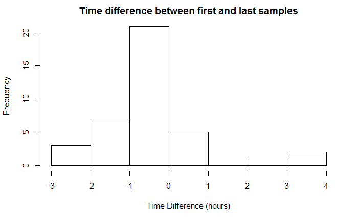

```r
tmp <- dlply(datanew.pkd, .(Patient.Number), function(data) {
  x <- as.character(data$Time.Sample.Taken)
  last <- length(x)
  as.duration(interval(x[last],x[1]))/3600
})
hist(unlist(tmp), main = "Time difference between first and last samples", xlab = "Time Difference (hours)")
```

Time difference between values given for first and final sample for each individual is far less than 24 hours…

Due to the fact that the date never changes from the 30th December 1899 despite a day having passed by the 24 hour sample taken.

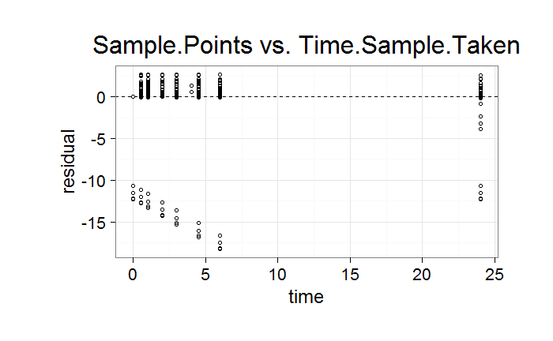

```r
nrow <- dim(datanew.pkd)[1]
tmp <- ddply(datanew.pkd[-nrow,], .(Patient.Number), function(data) {
  obs.time <- as.character(format(data$Time.Sample.Taken, "%H:%M:%S"))
  obs.date <- as.character(data$Sample.Date)
  obs.dt <- paste(obs.date, obs.time)
  obs <- as.numeric(as.duration(interval(obs.dt[1], obs.dt))/3600)
  pre <- data$Sample.Points
  res <- obs - pre
  data.frame(time = pre, residual = res)
})
plotobj <- NULL
plotobj <- ggplot(tmp, aes(x=time, y=residual))
plotobj <- plotobj + ggtitle("Sample.Points vs. Time.Sample.Taken")
plotobj <- plotobj + geom_point(shape = 21)
plotobj <- plotobj + geom_hline(yintercept = 0, linetype = "dashed")
plotobj
```

Difference between the two values are not larger than 5 for the most part.. however there are 3-4 cases where the residuals are quite high…

```r
res.id <- unique(tmp[abs(tmp$residual)>=5,]$Patient.Number)
sub.cols <- names(datanew.pkd) %in% c("Patient.Number","Sample.Date",
                     "Sample.Points","Time.Sample.Taken")
sub.data <- print(datanew.pkd[datanew.pkd$Patient.Number %in% res.id,sub.cols])
```

| Patient.Number | Sample.Date | Sample.Points | Time.Sample.Taken |
| --- | --- | --- | --- |
| 8834-30 | 2013-11-12 | 0.0 | 1899-12-30 10:40:00 |
| 8834-30 | 2013-11-12 | 0.5 | 1899-12-30 12:10:00 |
| 8834-30 | 2013-11-12 | 1.0 |  |
| 8834-30 | 2013-11-12 | 2.0 | 1899-12-30 13:42:00 |
| 8834-30 | 2013-11-12 | 3.0 | 1899-12-30 14:46:00 |
| 8834-30 | 2013-11-12 | 4.5 | 1899-12-30 16:10:00 |
| 8834-30 | 2013-11-12 | 6.0 | 1899-12-30 17:40:00 |
| 8834-30 | 2013-11-13 | 24.0 | 1899-12-30 11:45:00 |
| 8834-49 | 2014-04-07 | 0.0 | 1899-12-30 11:33:00 |
| 8834-49 | 2014-04-07 | 0.5 | 1899-12-30 12:05:00 |

[output cut: 22 more lines]

It appears there are NA’s in the Time.Sample.Taken column for these patients. For these values it would probably be best to assume that Time.Sample.Taken is equal to Sample.Points. Is returning large residuals due to lubridate’s handle on converting a date pasted to an NA

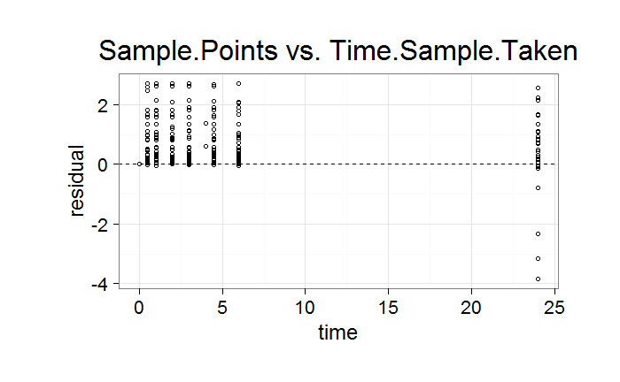

```r
nrow <- dim(datanew.pkd)[1]
tmp <- ddply(datanew.pkd[-nrow,], .(Patient.Number), function(data) {
  pre <- data$Sample.Points
  obs.time <- data$Time.Sample.Taken
  obs.date <- data$Sample.Date
  if(any(is.na(obs.time))) {
    x <- which(is.na(obs.time))
    obs.time[x] <- obs.time[x-1] + (pre[x]-pre[x-1])*3600
  }
  obs.dt <- paste(as.character(obs.date), format(obs.time, "%H:%M:%S"))
  obs <- as.numeric(as.duration(interval(obs.dt[1], obs.dt))/3600)
  res <- obs - pre
  data.frame(time = pre, residual = res)
})
plotobj <- NULL
plotobj <- ggplot(tmp, aes(x=time, y=residual))
plotobj <- plotobj + ggtitle("Sample.Points vs. Time.Sample.Taken")
plotobj <- plotobj + geom_point(shape = 21)
plotobj <- plotobj + geom_hline(yintercept = 0, linetype = "dashed")
plotobj
```

These NAs have been imputed by taking the previous number and adding the intended amount onwards. This gives it the same residual error as the point before hand. Ideally this should be imputed from the *actual dose time* if available so as not to predict residual error Additionally these values may be available in a separate data file

**Lenalidomide.Conc & The Rest**

```r
tail(with(datanew.pkd, table(Lenalidomide.Conc..nM., useNA = "always")))
```

```
Lenalidomide.Conc..nM.
97.052000000000007 97.346000000000004 99.036000000000001                 BD                 ND               <NA>
                 1                  1                  1                  1                  7                  1
```

```r
tmp <- which(datanew.pkd$Lenalidomide.Conc..nM. == "BD")
datanew.pkd[(tmp-2):(tmp+2),]
```

| Sample.. | Trial.Number | Patient.Number | Sample.Date | Type | Sample.Points | Lenalidomide.Conc..nM. | Time.Sample.Taken | Quantity.of.Tubes | Sample.Type | Processed.By | Processed.On |
| --- | --- | --- | --- | --- | --- | --- | --- | --- | --- | --- | --- |
| 218 | 10156 | 8834-13 | 2012-12-03 | C5D1 | 4.5 | 68.977999999999994 | 1899-12-30 15:32:00 | 2 | Plasma | Ling | 2013-03-06 |
| 257 | 10156 | 8834-13 | 2012-12-03 | C5D1 | 6.0 | 40.874000000000002 | 1899-12-30 17:03:00 | 2 | Plasma | Ling | 2013-03-06 |
| 298 | 10156 | 8834-13 | 2012-12-04 | C5D2 | 24.0 | BD | 1899-12-30 10:55:00 | 2 | Plasma | Ling | 2013-03-06 |
| 12 | 10156 | 8834-15 | 2012-12-10 | C5D1 | 0.0 | 1.3720000000000001 | 1899-12-30 10:30:00 | 2 | Plasma | Ling | 2013-03-06 |
| 53 | 10156 | 8834-15 | 2012-12-10 | C5D1 | 0.5 | 351.39 | 1899-12-30 11:04:00 | 2 | Plasma | Ling | 2013-03-06 |

Tail of table to search for NA values: seems there is one true NA (final row of the data), but also 7 ND and 1 BD. ND would be none detected. BD appears to be a typo, should be ND. These characters should be set to NA.

```r
with(datanew.pkd, table(Type, useNA = "always"))
```

```
Type
C2D1 C2D2 C5D1 C5D2 <NA>
 152   16  146   14    1
```

```r
with(datanew.pkd, table(Sample.Points, useNA = "always"))
```

```
Sample.Points
   0  0.5    1    2    3    4  4.5    6   24 <NA>
  41   41   41   41   41    2   39   41   41    1
```

Everything is fine here.

##### **Summary of Issues**

- Final row is full of NAs
- Penultimate row is missing values
- The Sample.Date and Time.Sample.Taken will need to be combined
- Replace ND and BD in Lenalidomide.Conc..nM. with NAs
- Patient.Number 8834-30, 8834-34, 8834-49, 8834-55 will need some imputation for Time.Sample.Taken
  - Either by assuming half-hour sample times have zero residuals
  - Or by finding the actual dose time and imputing from there

#### First Tab of “Data_PK analysis” (rawdata-lena_10156_datapk_excel.xlsx)

| Sequence.No | ID | age | gender | weight | height |
| --- | --- | --- | --- | --- | --- |
| 8834-01 | 1 | 53 | M | 65.55 | 175.3 |
| 8834-02 | 2 | 57 | M | 101.15 | 182.9 |
| 8834-03 | 3 | 68 | M | 98.70 | 172.7 |
| 8834-04 | 4 | 62 | F | 100.52 | 167.6 |
| 8834-05 | 5 | 59 | F | 175.30 | 59.7 |
| 8834-06 | 6 | 69 | M | 115.67 | 177.8 |

##### **Checking for errors in data**

**Sequence.No**

```r
with(datapk.demog, table(Sequence.No, useNA = "always"))
```

```
Sequence.No
8824-51 8834-01 8834-02 8834-03 8834-04 8834-05 8834-06 8834-07 8834-10 8834-11 8834-12 8834-13 8834-14 8834-15
      1       1       1       1       1       1       1       1       1       1       1       1       1       1
8834-16 8834-17 8834-18 8834-19 8834-20 8834-21 8834-22 8834-23 8834-24 8834-25 8834-26 8834-27 8834-28 8834-29
      1       1       1       1       1       1       1       1       1       1       1       1       1       1
8834-30 8834-31 8834-32 8834-33 8834-34 8834-35 8834-36 8834-37 8834-38 8834-39 8834-40 8834-41 8834-42 8834-43
      1       1       1       1       1       1       1       1       1       1       1       1       1       1
8834-45 8834-47 8834-49 8834-53 8834-55 8834-57 8834-59    <NA>
      1       1       1       1       1       1       1       0
```

No NAs which is good, however 8834-23b is missing. What else is missing?

```r
tmp <- list(
  pkd.id = unique(na.omit(datanew.pkd$Patient.Number)),
  demog.id = unique(datapk.demog$Sequence.No)
)
tmp1 <- which(tmp$demog.id %in% tmp$pkd.id)
tmp2 <- which(!tmp$pkd.id %in% tmp$demog.id)
id.length <- print(c(
  pkd.length = length(tmp$pkd.id),
  demog.length = length(tmp$demog.id),
  pkd.in.demog.length = length(tmp1)
))
```

```
         pkd.length        demog.length pkd.in.demog.length
                 41                  49                  40
```

```r
tmp$pkd.id[tmp2]
```

```
[1] "8834-23b"
```

This data sheet has 8 more patients than datanew.pkd. All of the datanew.pkd patients are accounted for excect for one, 8834-23b.

Hypotheses:

- The patient is in this new dataset, but with a different patient ID
- The patient is not in the dataset, therefore there are 9 more patients than in datanew.pkd

**Demographic Data**

```r
with(datapk.demog, table(ID, useNA = "always"))
```

```
ID
   1    2    3    4    5    6    7   10   11   12   13   14   15   16   17   18   19   20   21   22   23   24   25
   1    1    1    1    1    1    1    1    1    1    1    1    1    1    1    1    1    1    1    1    1    1    1
  26   27   28   29   30   31   32   33   34   35   36   37   38   39   40   41   42   43   45   47   49   51   53
   1    1    1    1    1    1    1    1    1    1    1    1    1    1    1    1    1    1    1    1    1    1    1
  55   57   59 <NA>
   1    1    1    0
```

```r
with(datapk.demog, table(age, useNA = "always"))
```

```
age
  40   41   46   48   50   51   52   53   56   57   58   59   61   62   63   64   65   66   67   68   69   70 <NA>
   1    1    1    1    1    1    3    3    3    6    2    2    4    2    2    2    1    3    3    5    1    1    0
```

```r
with(datapk.demog, table(gender, useNA = "always"))
```

```
gender
   F    M <NA>
  15   34    0
```

```r
with(datapk.demog, table(weight, useNA = "always"))
```

```
weight
 53.98  60.78   62.5  63.05   64.3  64.59   65.2  65.55   67.2  68.13     77     78   78.6   81.1   81.3  81.47
     1      1      1      1      1      1      1      1      1      1      1      1      1      1      1      1
  82.4   84.5  84.77   84.8   85.1  88.91   91.3   92.4   93.8  96.16  96.84   97.2   98.3  98.61   98.7 100.52
     1      1      1      1      1      1      1      1      1      1      1      1      1      1      1      1
 100.6    101 101.15  102.1  104.2  104.9  109.4  113.5 115.58 115.67 117.39 119.75  120.7 133.45  145.6  169.5
     1      1      1      1      1      1      1      1      1      1      1      1      1      1      1      1
 175.3   <NA>
     1      0
```

```r
with(datapk.demog, table(height, useNA = "always"))
```

```
height
 59.7 86.64 158.8   160 161.9 162.6 163.8 165.1 166.4 167.6 168.3 168.9 170.1 170.2 172.7   174 175.3 177.8 179.7
    1     1     1     1     1     2     1     2     2     2     1     2     1     1     3     2     2     4     1
180.3 182.9 184.2 185.4   188 190.5  <NA>
    1     9     1     4     1     2     0
```

#### Sixth Tab of “Data_PK analysis” (rawdata-lena_10156_datapk_excel.xlsx)

| SEQUENCE_NO_ | SEGMENT | ARM | FIRST_DOSE_DATE | START_TIME | COURSE_NUMBER | DRUG | DOSE_LEVEL | DOSE_UNITS | ACTUAL_DOSE | ACTUAL_DOSE_UNITS |
| --- | --- | --- | --- | --- | --- | --- | --- | --- | --- | --- |
| 8824-51 | Arm B Treatment | PCV13: 0.5mL IM D1C1/3; C4: Lenalidomide: 2.5mg PO QD; C5+: Lenalidomide: 5mg PO QD Sequential | 2014-03-18 | 11:15 | Cycle 1 | Pneumococcal 13-valent Conjugated Vaccine (Prevnar 13) (NSC# 754576) | 0.5 | mL | 0.5 | mL |
| 8824-51 | Arm B Treatment | PCV13: 0.5mL IM D1C1/3; C4: Lenalidomide: 2.5mg PO QD; C5+: Lenalidomide: 5mg PO QD Sequential | 2014-05-13 | 11:17 | Cycle 3 | Pneumococcal 13-valent Conjugated Vaccine (Prevnar 13) (NSC# 754576) | 0.5 | mL | 0.5 | mL |
| 8824-51 | Arm B Treatment | PCV13: 0.5mL IM D1C1/3; C4: Lenalidomide: 2.5mg PO QD; C5+: Lenalidomide: 5mg PO QD Sequential | 2014-06-10 | NA | Cycle 4 | CC-5013 (lenalidomide, Revlimid) NSC# 703813 | 2.5 | mg | 70.0 | mg |
| 8824-51 | Arm B Treatment | PCV13: 0.5mL IM D1C1/3; C4: Lenalidomide: 2.5mg PO QD; C5+: Lenalidomide: 5mg PO QD Sequential | 2014-07-08 | NA | Cycle 5 | CC-5013 (lenalidomide, Revlimid) NSC# 703813 | 5.0 | mg | 140.0 | mg |
| 8824-51 | Arm B Treatment | PCV13: 0.5mL IM D1C1/3; C4: Lenalidomide: 2.5mg PO QD; C5+: Lenalidomide: 5mg PO QD Sequential | 2014-08-05 | NA | Cycle 6 | CC-5013 (lenalidomide, Revlimid) NSC# 703813 | 5.0 | mg | 140.0 | mg |
| 8824-51 | Arm B Treatment | PCV13: 0.5mL IM D1C1/3; C4: Lenalidomide: 2.5mg PO QD; C5+: Lenalidomide: 5mg PO QD Sequential | 2014-09-04 | NA | Cycle 7 | CC-5013 (lenalidomide, Revlimid) NSC# 703813 | 5.0 | mg | 130.0 | mg |

##### **Checking for errors in data**

**Sequence_No**_

```r
datapk.dose$SEQUENCE_NO_ %>% table(useNA = "always")
```

```
.
8824-51 8834-01 8834-02 8834-03 8834-04 8834-05 8834-06 8834-07 8834-10 8834-11 8834-12 8834-13 8834-14 8834-15
     32      62       5      54      61      57      60      33      54       2      51      27      49      26
8834-16 8834-17 8834-18 8834-19 8834-20 8834-21 8834-22 8834-23 8834-24 8834-25 8834-26 8834-27 8834-28 8834-29
     49      50      49      11      45      46      12      42      46      37      36      39       2      43
8834-30 8834-31 8834-32 8834-33 8834-34 8834-35 8834-36 8834-37 8834-38 8834-39 8834-40 8834-41 8834-42 8834-43
     40      47      21      34      32      42      33       4       1      11      29      42      21      34
8834-45 8834-47 8834-49 8834-53 8834-55 8834-57 8834-59    <NA>
     11      33       9      29      13      28      30       0
```

```r
c(id.length, dose.length = datapk.dose$SEQUENCE_NO_ %>% unique() %>% length())
```

```
         pkd.length        demog.length pkd.in.demog.length         dose.length
                 41                  49                  40                  49
```

```r
tmp1 <- datapk.demog$Sequence.No
tmp2 <- datapk.dose$SEQUENCE_NO_
c(
  all.match = !any(!tmp2 %in% tmp1),
  any.23b = any(datapk.dose$SEQUENCE_NO_ == "8834-23b")
)
```

```
all.match   any.23b
     TRUE     FALSE
```

Once again we have an extra 8-9 patients and missing patient 23b. datapk.demog and datapk.dose have the same ID sets.

**START_TIME**

```r
datapk.dose$START_TIME %>% table(useNA = "always") %>% tail()
```

```
.
16:59 17:00 17:42 18:00 21:00  <NA>
    1     1     1     1     1  1465
```

The dose times at the start of each cycle are not numerous, with 1465 values not entered. The majority don’t matter, however the times that match up with the cycles in datanew.pkd do matter.

**COURSE_NUMBER**

```r
datapk.dose$COURSE_NUMBER %>% unique() %>% length()
```

```
[1] 128
```

```r
datapk.dose$COURSE_NUMBER %>% table(useNA = "always") %>% tail()
```

```
.
cycle11 CYCLE11 Cycle23 Cycle24 Cycle37    <NA>
      1       1       1       1       1       0
```

A large number of unique cycle numbers, but no NAs which is good. Will need to extract the number from each cell.

**Dose Date & The Rest**

```r
tail(with(datapk.dose, table(FIRST_DOSE_DATE, useNA="always")))
```

```
FIRST_DOSE_DATE
2016-08-15 2016-08-16 2016-08-22 2016-08-23 2105-03-31       <NA>
         5          2          3          2          1          0
```

```r
with(datapk.dose, table(DRUG, useNA="always"))
```

```
DRUG
                        CC-5013 (lenalidomide, Revlimid) NSC# 703813
                                                                1529
Pneumococcal 13-valent Conjugated Vaccine (Prevnar 13) (NSC# 754576)
                                                                  93
                                                                <NA>
                                                                   2
```

```r
with(datapk.dose, table(DOSE_LEVEL, useNA="always"))
```

```
DOSE_LEVEL
   0  0.5  2.5    5   24 <NA>
   1   93  297 1232    1    0
```

```r
with(datapk.dose, table(DOSE_UNITS, useNA="always"))
```

```
DOSE_UNITS
IU/mL    mg    mL  <NA>
    1  1533    90     0
```

#### Collation of Data

##### **Matching up cycles to determine dose times**

```r
dose.cycles <- datapk.dose$COURSE_NUMBER %>%
  strsplit("[^0-9]+") %>%
  unlist() %>%
  as.numeric() %>%
  na.omit()
length(dose.cycles) == dim(datapk.dose)[1]
```

```
[1] TRUE
```

```r
table(dose.cycles, useNA = "always")
```

```
dose.cycles
   1    2    3    4    5    6    7    8    9   10   11   12   13   14   15   16   17   18   19   20   21   22   23
  49   23   67   47   68   45   45   42   43   38   40   39   38   37   37   37   38   38   38   38   39   38   36
  24   25   26   27   28   29   30   31   32   33   34   35   36   37   38   39   40   41   42   43   44   45   46
  36   36   36   36   36   35   32   30   29   26   25   24   22   22   21   20   20   18   18   18   12   13   12
  47   48   49   50   51   52   53   54   55   56   57   58   59   60   61   62   63 <NA>
  10    8    8    8    8    8    7    6    6    4    4    2    2    2    2    1    1    0
```

Split the cycle number away from the word cycle. REMINDER: Some cycles refer to lenalidomide, others refer to the vaccine. Need to subset before collation!

```r
pkd.cd <- na.omit(datanew.pkd$Type) %>%
  strsplit("[^0-9]+") %>%
  unlist() %>%
  as.numeric() %>%
  na.omit()
tmp <- length(pkd.cd)/2
pkd.cycle <- pkd.cd[1:tmp*2-1]
pkd.day <- pkd.cd[1:tmp*2] + 28*(pkd.cycle-1)
list(
  unique.cycles = unique(pkd.cycle),
  unique.days = unique(pkd.day),
  equal.length = dim(datanew.pkd)[1] == length(pkd.day) &
    dim(datanew.pkd)[1] == length(pkd.cycle)
)
```

```
$unique.cycles
[1] 2 5

$unique.days
[1]  29  30 113 114

$equal.length
[1] FALSE
```

Lengths not equal due to NA row at the bottom of datanew.pkd.

Desire to match up cycles to dose times, however issue still remains with ID 8834-23b. To find out which ID matches with 8834-23b the repeated information between data.frames must be used.

- FIRST_DOSE_DATE & Sample.Date
  - The date of the samples should match up with the stat of the cycle
- SEGMENT & Type
  - Samples taken on cycle 2 -> Arm A
  - Samples taken on cycle 5 -> Arm B

```r
tmp1 <- datanew.pkd[datanew.pkd$Patient.Number == "8834-23b",]
tmp2 <- pkd.cycle[datanew.pkd$Patient.Number == "8834-23b"]
tmp <- list(
  tmp1$Sample.Date[1],
  paste("Arm", ifelse(tmp2[1] == 2, "A", "B"), "Treatment")
)
data.match <- datapk.dose[datapk.dose$FIRST_DOSE_DATE == tmp[1],]
tmp <- print(list(
  matched.ids = data.match$SEQUENCE_NO_[data.match$SEGMENT == tmp[2]],
  id.in.pkd = data.match$SEQUENCE_NO_[data.match$SEGMENT == tmp[2]] %in%
    datanew.pkd$Patient.Number
))
```

```
$matched.ids
[1] "8834-01" "8834-17" "8834-27" "8834-29"

$id.in.pkd
[1]  TRUE  TRUE  TRUE FALSE
```

Four IDs match the sample date and treatment arm of 8834-23b and only one of them is not present in the pkd dataset. Therefore 8834-29 is the most likely candidate to be 8834-23b.

```r
datapk.dose$CYCLE <- dose.cycles
datanew <- datanew.pkd[-dim(datanew.pkd)[1], ]
datanew$Day <- pkd.day
datanew$Cycle <- pkd.cycle
datanew$Patient.Number[datanew$Patient.Number == "8834-23b"] <-
  tmp$matched.ids[!tmp$id.in.pkd]
datapk.sub <- ddply(datanew, .(Patient.Number), function(x) {
  y <- datapk.dose
  cid <- unique(x$Patient.Number)
  cycle <- unique(x$Cycle)
  sub.cond <- y$SEQUENCE_NO_ == cid & y$CYCLE == cycle
  sub.y <- datapk.dose[sub.cond, ]
})
with(datapk.sub, table(START_TIME, useNA = "always"))
```

```
START_TIME
09:43 10:10 10:30 11:18 11:41 12:25 12:35 12:45  <NA>
    1     1     1     1     1     1     1     1    33
```

Remove final row of datanew.pkd to start creating final data.frame “datanew”. Then using the unique cycle numbers determine whether there are dose starting times for those IDs.

There are 8 IDs out of the 41 that have matched start times. There are a few options to handle this.

- Use the start times to determine what is time == 0
  - Problematic due to only 8 IDs having this information
- Assume that time == 0.5 is correct, thus determining time == 0
  - Good because everyone has a time == 0.5 with corresponding sample time
  - While not exact, earlier sample times should have lower time error
- Use a mixture of the two!
  - Exact start time when available, but time == 0.5 for the rest

```r
tmp1 <- datapk.sub$SEQUENCE_NO_[!is.na(datapk.sub$START_TIME)]
tmp2 <- datanew[datanew$Patient.Number %in% tmp1, ]
nrow <- dim(datanew)[1]
tmp <- ddply(tmp2, .(Patient.Number), function(data) {
  cid <- unique(data$Patient.Number)
  start.sub <- datapk.sub[datapk.sub$SEQUENCE_NO_ == cid,]
  start <- paste0(start.sub$FIRST_DOSE_DATE, " ", start.sub$START_TIME, ":00")
  pre <- data$Sample.Points
  obs.time <- data$Time.Sample.Taken
  obs.date <- data$Sample.Date
  if(any(is.na(obs.time))) {
    x <- which(is.na(obs.time))
    obs.time[x] <- obs.time[x-1] + (pre[x]-pre[x-1])*3600
  }
  obs.dt <- paste(as.character(obs.date), format(obs.time, "%H:%M:%S"))
  obs <- as.numeric(as.duration(interval(start, obs.dt))/3600)
  res <- obs - pre
  data.frame(time = pre, residual = res)
})
tmp5 <- tmp
tmp3 <- print(tmp$residual[tmp$time == 0.5])
```

```
[1]  0.00000000  0.05000000 -0.01666667  0.51666667  0.45000000 -0.06666667 -0.01666667 -0.05000000
```

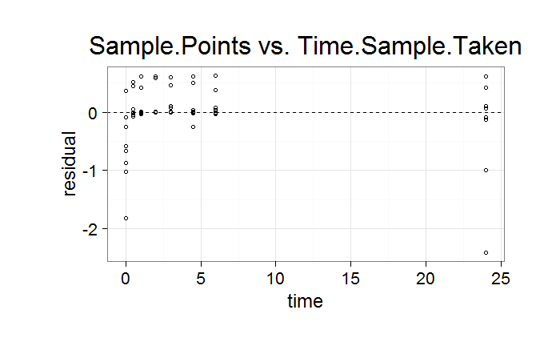

```r
plotobj <- NULL
plotobj <- ggplot(tmp, aes(x=time, y=residual))
plotobj <- plotobj + ggtitle("Sample.Points vs. Time.Sample.Taken")
plotobj <- plotobj + geom_point(shape = 21)
plotobj <- plotobj + geom_hline(yintercept = 0, linetype = "dashed")
plotobj
```

**Dilemna**: Two of the patients 8834-05, 8834-07 have a large residual at time == 0.5 (relative error of ~100%). This is pretty excessive making the idea of using a mixed approach sound less ideal.

It raises the question of datapk.dose’s accuracy in dose start times. If that many times have not been entered, then how accurate are the ones that have been?

**Decision**: Will assume time == 0.5 is correct for now. This may change on observing the individual plots.

Each patient requires times to be set so that dosing begins on the imputed dose time. This is calculated by subtracting 30 minutes from the sample time allocated to a Sample.Points value of 0.5. Using this time dosing will start 28 days beforehand at that time. As a result the last dose given before concentrations are taken will have been given at time == 672.

```r
tmp <- datanew$Sample.Points
tmp1 <- datanew$Time.Sample.Taken
tmp2 <- datanew$Sample.Date
if(any(is.na(tmp1))) {
  x <- which(is.na(tmp1))
  tmp1[x] <- tmp1[x-1] + (tmp[x]-tmp[x-1])*3600
}
datanew$DateTime <- paste(as.character(tmp2), format(tmp1, "%H:%M:%S"))
int2dur.hours <- function(x, y) {
  as.numeric(as.duration(interval(x, y))/3600)
}
new.times <- print(ddply(datanew, .(Patient.Number), function(data) {
  x <- data$DateTime[data$Sample.Points == 0.5]
  TALD <- as.POSIXct(x, tz = "GMT") - 60*30
  zero <- as.character(TALD - 60*60*24*28)
  data.frame(
    Sample.Points = data$Sample.Points,
    TIME = int2dur.hours(zero, data$DateTime),
    TAD = int2dur.hours(as.character(TALD), data$DateTime)
  )
}))
```

| Patient.Number | Sample.Points | TIME | TAD |
| --- | --- | --- | --- |
| 8834-01 | 0.0 | 670.1833 | -1.81666667 |
| 8834-01 | 0.5 | 672.5000 | 0.50000000 |
| 8834-01 | 1.0 | 672.9833 | 0.98333333 |
| 8834-01 | 2.0 | 674.0000 | 2.00000000 |
| 8834-01 | 3.0 | 675.0833 | 3.08333333 |
| 8834-01 | 4.5 | 676.5000 | 4.50000000 |
| 8834-01 | 6.0 | 677.9667 | 5.96666667 |
| 8834-01 | 24.0 | 695.0000 | 23.00000000 |
| 8834-02 | 0.0 | 671.7000 | -0.30000000 |
| 8834-02 | 0.5 | 672.5000 | 0.50000000 |

[output cut: 318 more lines]

##### **Dosing of patients**

```r
tmp <- ddply(datanew, .(Patient.Number), function(x) {
  y <- datapk.dose
  cid <- unique(x$Patient.Number)
  cycle <- unique(x$Cycle)
  sub.cond <- y$SEQUENCE_NO_ == cid & y$CYCLE %in% c(cycle, cycle - 1)
  sub.y <- datapk.dose[sub.cond, ]
})
dim(tmp)[1]
```

```
[1] 82
```

```r
with(tmp, table(DOSE_LEVEL, useNA = "always"))
```

```
DOSE_LEVEL
 2.5    5 <NA>
  41   41    0
```

Doses are not variable for the first two cycles of Len treatment (Arm A being 1 & 2, B being 4 & 5)

##### **Preparing data for pre-modeling analysis**

**Desired structure**: ID, STUDY, DOSEMG, AMT, EVID, TIME, TAD, MDV, LNDV, AGE, GEND, WT, HT, DXCAT, DVNORM, ADDL, II, CMT, OCC

```r
names(datapk.demog)[1] <- names(datanew)[3]
data.arm <- datapk.dose[c(1,2)] %>%
  data.frame() %>%
  rename(Patient.Number = SEQUENCE_NO_) %>%
  group_by(Patient.Number) %>%
  do(.[1, ])
datamerge <- datanew %>%
  merge(new.times) %>%
  merge(datapk.demog) %>%
  merge(data.arm)
nrow <- dim(datamerge)[1]
dvprep <- matrix(nrow = nrow, ncol = 23) %>% data.frame()
nmprep.names <- c("ID", "STUDY", "GRP", "DOSEMG", "AMT", "EVID", "TIME",
"TAD", "DAY", "DV", "MDV", "LNDV", "AGE", "GEND", "WT", "HT", "BSA", "DXCAT", "DVNORM",
"ADDL", "II", "CMT", "OCC")
names(dvprep) <- nmprep.names
dvprep.id <- datamerge$Patient.Number %>%
  strsplit("[^0-9]+") %>%
  unlist() %>%
  as.numeric() %>%
  na.omit()
dvprep.dv <- as.numeric(datamerge$Lenalidomide.Conc..nM.)
```

```
NAs introduced by coercion
```

```r
dvprep$ID <- dvprep.id[1:(nrow)*2]
dvprep$STUDY <- "10156"
dvprep$GRP <- ifelse(datamerge$SEGMENT == "Arm A Treatment", 1, 2)
dvprep$DOSEMG <- 5
dvprep$EVID <- 0
dvprep$TIME <- datamerge$TIME
dvprep$TAD <- datamerge$TAD
dvprep$TAD[dvprep$TAD < 0] <- dvprep$TAD[dvprep$TAD < 0] + 24
dvprep$TAD[dvprep$TAD >= 24] <- dvprep$TAD[dvprep$TAD >= 24] - 24
dvprep$DV <- dvprep.dv*259.26/(1000*1000) #convert from nM to ug/L to ug/mL
dvprep$MDV <- ifelse(is.na(dvprep$DV), 1, 0)
dvprep$LNDV <- log(dvprep$DV)
dvprep$AGE <- datamerge$age
dvprep$GEND <- datamerge$gender
dvprep$WT <- datamerge$weight
dvprep$HT <- datamerge$height
dvprep$BSA <- 0.007184 * dvprep$WT^0.425 * dvprep$HT^0.725
dvprep$DXCAT <- 1
dvprep$DVNORM <- dvprep$DV/dvprep$DOSEMG
dvprep$CMT <- 2
dvprep$OCC <- 2
dvprep
```

| ID | STUDY | GRP | DOSEMG | AMT | EVID | TIME | TAD | DAY | DV | MDV | LNDV | AGE | GEND | WT | HT | BSA | DXCAT | DVNORM | ADDL | II | CMT | OCC |
| --- | --- | --- | --- | --- | --- | --- | --- | --- | --- | --- | --- | --- | --- | --- | --- | --- | --- | --- | --- | --- | --- | --- |
| 1 | 10156 | 2 | 5 | NA | 0 | 670.1833 | 22.18333333 | NA | 0.0018277830 | 0 | -6.304652 | 53 | M | 65.55 | 175.30 | 1.799499 | 1 | 3.655566e-04 | NA | NA | 2 | 2 |
| 1 | 10156 | 2 | 5 | NA | 0 | 672.5000 | 0.50000000 | NA | 0.0087552102 | 0 | -4.738106 | 53 | M | 65.55 | 175.30 | 1.799499 | 1 | 1.751042e-03 | NA | NA | 2 | 2 |
| 1 | 10156 | 2 | 5 | NA | 0 | 672.9833 | 0.98333333 | NA | 0.0134530014 | 0 | -4.308553 | 53 | M | 65.55 | 175.30 | 1.799499 | 1 | 2.690600e-03 | NA | NA | 2 | 2 |
| 1 | 10156 | 2 | 5 | NA | 0 | 674.0000 | 2.00000000 | NA | 0.0184333860 | 0 | -3.993592 | 53 | M | 65.55 | 175.30 | 1.799499 | 1 | 3.686677e-03 | NA | NA | 2 | 2 |
| 1 | 10156 | 2 | 5 | NA | 0 | 695.0000 | 23.00000000 | NA | 0.0014337078 | 0 | -6.547491 | 53 | M | 65.55 | 175.30 | 1.799499 | 1 | 2.867416e-04 | NA | NA | 2 | 2 |
| 1 | 10156 | 2 | 5 | NA | 0 | 675.0833 | 3.08333333 | NA | 0.0192293142 | 0 | -3.951319 | 53 | M | 65.55 | 175.30 | 1.799499 | 1 | 3.845863e-03 | NA | NA | 2 | 2 |
| 1 | 10156 | 2 | 5 | NA | 0 | 676.5000 | 4.50000000 | NA | 0.0113348472 | 0 | -4.479873 | 53 | M | 65.55 | 175.30 | 1.799499 | 1 | 2.266969e-03 | NA | NA | 2 | 2 |
| 1 | 10156 | 2 | 5 | NA | 0 | 677.9667 | 5.96666667 | NA | 0.0112155876 | 0 | -4.490451 | 53 | M | 65.55 | 175.30 | 1.799499 | 1 | 2.243118e-03 | NA | NA | 2 | 2 |
| 2 | 10156 | 2 | 5 | NA | 0 | 671.7000 | 23.70000000 | NA | NA | 1 | NA | 57 | M | 101.15 | 182.90 | 2.231422 | 1 | NA | NA | NA | 2 | 2 |
| 2 | 10156 | 2 | 5 | NA | 0 | 672.5000 | 0.50000000 | NA | NA | 1 | NA | 57 | M | 101.15 | 182.90 | 2.231422 | 1 | NA | NA | NA | 2 | 2 |

[output cut: 318 more lines]

The DV for the data has been collated and fixed for errors. NA’s will be converted to “.” after the addition of AMT values.

```r
nrow <- dvprep$ID %>% unique() %>% length()
amtprep <- ldply(1:nrow, function(i) {
  cid <- unique(dvprep$ID)[i]
  data.frame(
    ID = cid,
    STUDY = "10156",
    GRP = dvprep$GRP[dvprep$ID == cid] %>% unique(),
    DOSEMG = c(2.5, 5),
    AMT = c(2.5, 5),
    EVID = 1,
    TIME = c(0, 672),
    TAD = 0,
    DAY = NA,
    DV = NA,
    MDV = 1,
    LNDV = NA,
    AGE = dvprep$AGE[dvprep$ID == cid] %>% unique(),
    GEND = dvprep$GEND[dvprep$ID == cid] %>% unique(),
    WT = dvprep$WT[dvprep$ID == cid] %>% unique(),
    HT = dvprep$HT[dvprep$ID == cid] %>% unique(),
    BSA = dvprep$BSA[dvprep$ID == cid] %>% unique(),
    DXCAT = 1,
    DVNORM = NA,
    ADDL = c(27, 1),
    II = 24,
    CMT = 1,
    OCC = c(1, 2)
  )
})
any(names(amtprep) != names(dvprep))
```

```
[1] FALSE
```

```r
amtprep
```

| ID | STUDY | GRP | DOSEMG | AMT | EVID | TIME | TAD | DAY | DV | MDV | LNDV | AGE | GEND | WT | HT | BSA | DXCAT | DVNORM | ADDL | II | CMT | OCC |
| --- | --- | --- | --- | --- | --- | --- | --- | --- | --- | --- | --- | --- | --- | --- | --- | --- | --- | --- | --- | --- | --- | --- |
| 1 | 10156 | 2 | 2.5 | 2.5 | 1 | 0 | 0 | NA | NA | 1 | NA | 53 | M | 65.55 | 175.30 | 1.799499 | 1 | NA | 27 | 24 | 1 | 1 |
| 1 | 10156 | 2 | 5.0 | 5.0 | 1 | 672 | 0 | NA | NA | 1 | NA | 53 | M | 65.55 | 175.30 | 1.799499 | 1 | NA | 1 | 24 | 1 | 2 |
| 2 | 10156 | 2 | 2.5 | 2.5 | 1 | 0 | 0 | NA | NA | 1 | NA | 57 | M | 101.15 | 182.90 | 2.231422 | 1 | NA | 27 | 24 | 1 | 1 |
| 2 | 10156 | 2 | 5.0 | 5.0 | 1 | 672 | 0 | NA | NA | 1 | NA | 57 | M | 101.15 | 182.90 | 2.231422 | 1 | NA | 1 | 24 | 1 | 2 |
| 3 | 10156 | 2 | 2.5 | 2.5 | 1 | 0 | 0 | NA | NA | 1 | NA | 68 | M | 98.70 | 172.70 | 2.118303 | 1 | NA | 27 | 24 | 1 | 1 |
| 3 | 10156 | 2 | 5.0 | 5.0 | 1 | 672 | 0 | NA | NA | 1 | NA | 68 | M | 98.70 | 172.70 | 2.118303 | 1 | NA | 1 | 24 | 1 | 2 |
| 4 | 10156 | 1 | 2.5 | 2.5 | 1 | 0 | 0 | NA | NA | 1 | NA | 62 | F | 100.52 | 167.60 | 2.088922 | 1 | NA | 27 | 24 | 1 | 1 |
| 4 | 10156 | 1 | 5.0 | 5.0 | 1 | 672 | 0 | NA | NA | 1 | NA | 62 | F | 100.52 | 167.60 | 2.088922 | 1 | NA | 1 | 24 | 1 | 2 |
| 5 | 10156 | 1 | 2.5 | 2.5 | 1 | 0 | 0 | NA | NA | 1 | NA | 59 | F | 175.30 | 59.70 | 1.251858 | 1 | NA | 27 | 24 | 1 | 1 |
| 5 | 10156 | 1 | 5.0 | 5.0 | 1 | 672 | 0 | NA | NA | 1 | NA | 59 | F | 175.30 | 59.70 | 1.251858 | 1 | NA | 1 | 24 | 1 | 2 |

[output cut: 72 more lines]

Names of both amtprep and dvprep are the same, so they are find to be joined together and ordered.

```r
nmprep <- dvprep %>% rbind(amtprep) %>% arrange(ID, TIME)
nmprep
```

| ID | STUDY | GRP | DOSEMG | AMT | EVID | TIME | TAD | DAY | DV | MDV | LNDV | AGE | GEND | WT | HT | BSA | DXCAT | DVNORM | ADDL | II | CMT | OCC |
| --- | --- | --- | --- | --- | --- | --- | --- | --- | --- | --- | --- | --- | --- | --- | --- | --- | --- | --- | --- | --- | --- | --- |
| 1 | 10156 | 2 | 2.5 | 2.5 | 1 | 0.0000 | 0.00000000 | NA | NA | 1 | NA | 53 | M | 65.55 | 175.30 | 1.799499 | 1 | NA | 27 | 24 | 1 | 1 |
| 1 | 10156 | 2 | 5.0 | NA | 0 | 670.1833 | 22.18333333 | NA | 0.0018277830 | 0 | -6.304652 | 53 | M | 65.55 | 175.30 | 1.799499 | 1 | 3.655566e-04 | NA | NA | 2 | 2 |
| 1 | 10156 | 2 | 5.0 | 5.0 | 1 | 672.0000 | 0.00000000 | NA | NA | 1 | NA | 53 | M | 65.55 | 175.30 | 1.799499 | 1 | NA | 1 | 24 | 1 | 2 |
| 1 | 10156 | 2 | 5.0 | NA | 0 | 672.5000 | 0.50000000 | NA | 0.0087552102 | 0 | -4.738106 | 53 | M | 65.55 | 175.30 | 1.799499 | 1 | 1.751042e-03 | NA | NA | 2 | 2 |
| 1 | 10156 | 2 | 5.0 | NA | 0 | 672.9833 | 0.98333333 | NA | 0.0134530014 | 0 | -4.308553 | 53 | M | 65.55 | 175.30 | 1.799499 | 1 | 2.690600e-03 | NA | NA | 2 | 2 |
| 1 | 10156 | 2 | 5.0 | NA | 0 | 674.0000 | 2.00000000 | NA | 0.0184333860 | 0 | -3.993592 | 53 | M | 65.55 | 175.30 | 1.799499 | 1 | 3.686677e-03 | NA | NA | 2 | 2 |
| 1 | 10156 | 2 | 5.0 | NA | 0 | 675.0833 | 3.08333333 | NA | 0.0192293142 | 0 | -3.951319 | 53 | M | 65.55 | 175.30 | 1.799499 | 1 | 3.845863e-03 | NA | NA | 2 | 2 |
| 1 | 10156 | 2 | 5.0 | NA | 0 | 676.5000 | 4.50000000 | NA | 0.0113348472 | 0 | -4.479873 | 53 | M | 65.55 | 175.30 | 1.799499 | 1 | 2.266969e-03 | NA | NA | 2 | 2 |
| 1 | 10156 | 2 | 5.0 | NA | 0 | 677.9667 | 5.96666667 | NA | 0.0112155876 | 0 | -4.490451 | 53 | M | 65.55 | 175.30 | 1.799499 | 1 | 2.243118e-03 | NA | NA | 2 | 2 |
| 1 | 10156 | 2 | 5.0 | NA | 0 | 695.0000 | 23.00000000 | NA | 0.0014337078 | 0 | -6.547491 | 53 | M | 65.55 | 175.30 | 1.799499 | 1 | 2.867416e-04 | NA | NA | 2 | 2 |

[output cut: 400 more lines]

Data now in NONMEM format, ready for pre-modeling analysis.

#### Pre-Modeling Analysis

```r
plotobj <- qplot(x = DV, geom = "histogram", data = nmprep)
filename.out <- paste(data.dir,"Histogram_DV",sep="/")
suppressWarnings(to.png(plotobj,filename.out))
```

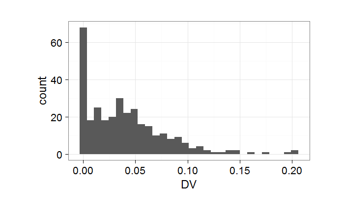

```r
plotobj
plotobj <- qplot(x = LNDV, geom = "histogram", data = nmprep)
filename.out <- paste(data.dir,"Histogram_DVlog",sep="/")
suppressWarnings(to.png(plotobj,filename.out))
```

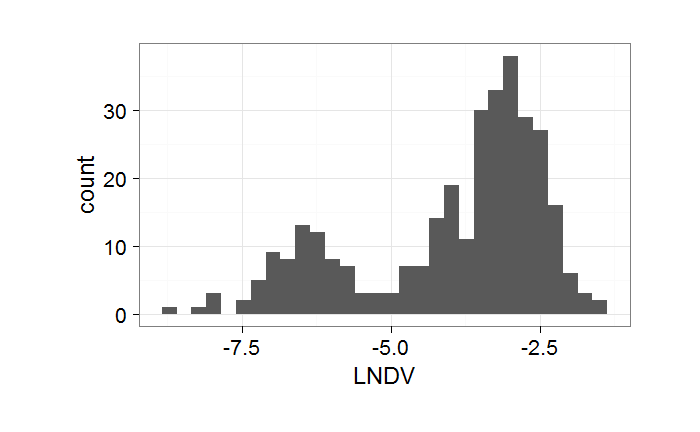

```r
plotobj
```

Data has a wide range of values, seems almost log-bimodal…

```r
DVcount <- summaryBy(DV ~ STUDY, data=nmprep, FUN=lengthNA)
names(DVcount) <- c("Group","DVcount")
SUBcount <- ddply(nmprep, .(STUDY), function(df) count.unique(df$ID))
names(SUBcount) <- c("Group","SUBcount")
AMTcount <- ddply(nmprep, .(STUDY), function(df) lengthNA(df$AMT))
names(AMTcount) <- c("Group","AMTcount")
DVsum <- cbind(DVcount,SUBcount[-1],AMTcount[-1])
DVsum$DVperSUB <-  round(DVsum$DVcount/DVsum$SUBcount,0)
DVsum$AMTperSUB <-  round(DVsum$AMTcount/DVsum$SUBcount,0)
filename.out <- paste(data.dir,"DVsum.csv",sep="/")
write.csv(DVsum, file=filename.out)
DVsum
```

|  | Group | DVcount | SUBcount | AMTcount | DVperSUB | AMTperSUB |
| --- | --- | --- | --- | --- | --- | --- |
| 1 | 10156 | 320 | 41 | 82 | 8 | 2 |

```r
plotobj <- NULL
titletext <- paste("Observed Concentrations\n")
plotobj <- ggplot(data = nmprep)
plotobj <- plotobj + ggtitle(titletext)
plotobj <- plotobj + geom_point(aes(x = TAD, y = DV),
  size = 1.5, alpha = 0.5, shape = 21)
plotobj <- plotobj + scale_y_log10("Concentration (ng/ml)")
plotobj <- plotobj + scale_x_continuous("Time after first dose (hours)")
filename.out <- paste(data.dir,"ConcObs_vs_TAD",sep="/")
to.png(plotobj,filename.out)
```

```r
plotobj
plotobj2 <- plotobj + facet_wrap(~ID)
filename.out <- paste(data.dir,"ConcObs_vs_TIME_byID",sep="/")
to.png(plotobj2,filename.out)
```

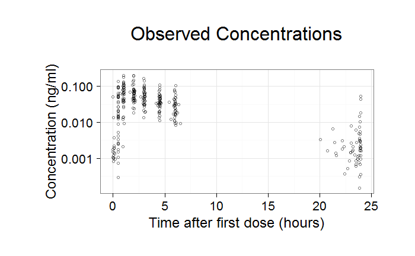

```r
plotobj3 <- plotobj + facet_wrap(~GRP)
filename.out <- paste(data.dir,"ConcObs_vs_TIME_byGRP",sep="/")
to.png(plotobj3,filename.out)
```

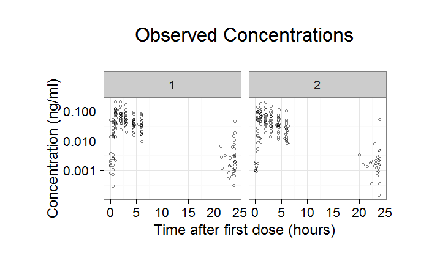

```r
plotobj3
```

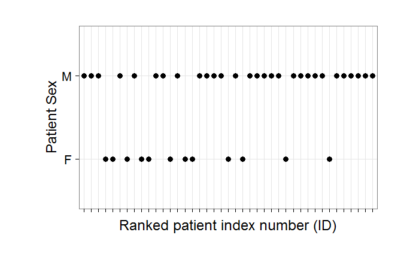

```r
nmprep.one <- lapplyBy(~ID, data=nmprep,  oneperID)
nmprep.one <- bind.list(nmprep.one)
nmprep.one$IDf <- factor(nmprep.one$ID)
plotIndexCont <- function(CovColname,CovText) {
  plotobj <- ggplot(data=nmprep.one)
  plotobj <- plotobj + geom_point(aes_string(y=CovColname, x="IDf"), size=3)
  plotobj <- plotobj + scale_x_discrete("Ranked patient index number (ID)")
  CovText <- eval(parse(text=CovText))  #GOLD turn text into expression
  plotobj <- plotobj + scale_y_continuous(name=CovText)
  plotobj <- plotobj + theme(axis.text.x = element_blank())
  filename.out <- paste(data.dir,"/IndexPlot_",CovColname,sep="")
  to.png.wx1(plotobj,filename.out)
  plotobj
}
plotIndexCat <- function(CovColname,CovText) {
  plotobj <- ggplot(data=nmprep.one)
  plotobj <- plotobj + geom_point(aes_string(y=CovColname, x="IDf"), size=3)
  plotobj <- plotobj + scale_x_discrete("Ranked patient index number (ID)")
  CovText <- eval(parse(text=CovText))  #GOLD turn text into expression
  plotobj <- plotobj + scale_y_discrete(name=CovText)
  plotobj <- plotobj + theme(axis.text.x = element_blank())
  filename.out <- paste(data.dir,"/IndexPlot_",CovColname,sep="")
  to.png.wx1(plotobj,filename.out)
  plotobj
}
plotIndexCat("GEND", "Patient~Sex")
```

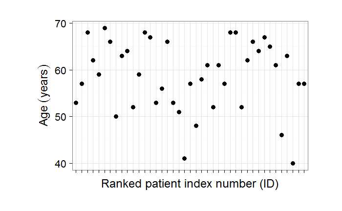

```r
plotIndexCont("AGE","Age~(years)")
```

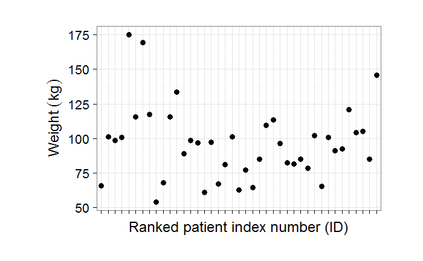

```r
plotIndexCont("WT","Weight~(kg)")
```

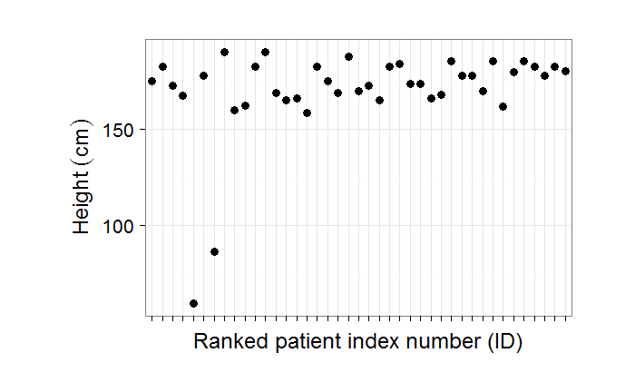

```r
plotIndexCont("HT","Height~(cm)")
```

Something a little weird about some of these heights.

```r
tmp <- print(nmprep.one[nmprep.one$HT < 100,] %>% select(ID, AGE, WT, HT))$ID
```

|  | ID | AGE | WT | HT |
| --- | --- | --- | --- | --- |
| 41 | 5 | 59 | 175.3 | 59.70 |
| 61 | 7 | 66 | 169.5 | 86.64 |

```r
tmp1 <- nmprep$WT[nmprep$ID %in% tmp]
nmprep$WT[nmprep$ID %in% tmp] <- nmprep$HT[nmprep$ID %in% tmp]
nmprep$HT[nmprep$ID %in% tmp] <- tmp1
```

It appears the height and weight for these patients have been switched. Switch this back for nmprep

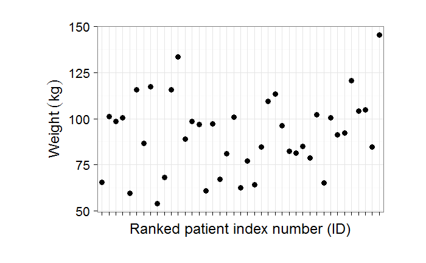

```r
nmprep.one <- lapplyBy(~ID, data=nmprep,  oneperID)
nmprep.one <- bind.list(nmprep.one)
nmprep.one$IDf <- factor(nmprep.one$ID)
plotIndexCont("WT","Weight~(kg)")
```

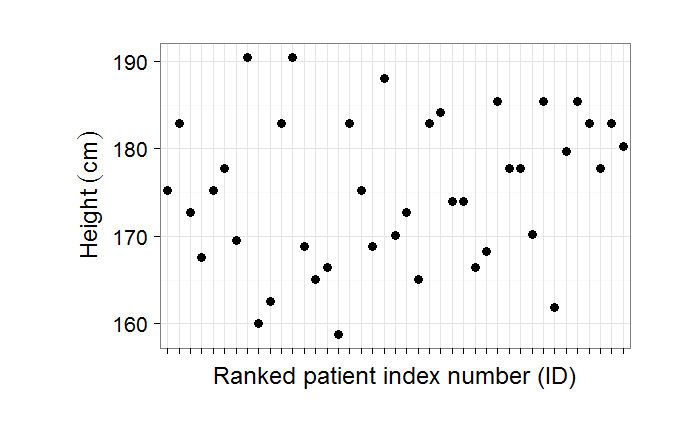

```r
plotIndexCont("HT","Height~(cm)")
```

This is ideal, save as output

```r
nmprep$DAY <- ceiling((nmprep$TIME+0.001)/24)
clean.data <- nmprep
nmprep[is.na(nmprep)] <- "."
names(nmprep)[1] <- "#ID"
nmprep$GEND[nmprep$GEND == "M"] <- 1
nmprep$GEND[nmprep$GEND == "F"] <- 0
ffm.var1 <- ifelse(nmprep$GEND == 1, 6.68, 8.78)
ffm.var2 <- ifelse(nmprep$GEND == 1, 216, 244)
nmprep$BMI <- nmprep$WT/(nmprep$HT/100)**2
nmprep$FFM <- 9.27 * 10^3 * nmprep$WT / (ffm.var1 * 10^3 + ffm.var2 * nmprep$BMI)
nmprep$FFM <-
filename.out <- paste(data.dir,"extval_10156.csv",sep="/")
write.csv(nmprep, file = filename.out, quote=FALSE, row.names = FALSE)
nmprep.one$GEND[nmprep.one$GEND == "M"] <- 1
nmprep.one$GEND[nmprep.one$GEND == "F"] <- 0
filename.out <- paste(data.dir, "10156_covdata.csv", sep="/")
write.csv(nmprep.one[c(1:4, 13:16)], file = filename.out, quote = FALSE, row.names = FALSE)
clean.data <- clean.data %>%
    select(c(ID, STUDY, AMT, TIME, TAD, DAY, DV, MDV,
      AGE, GEND, WT, HT, DXCAT)) %>%
    rename(SEX = GEND, DVMGL = DV, WTKG = WT, HTCM = HT, DOSEMG = AMT)
dxcat.l <- c("CLL", "AML", "ALL", "MM")
clean.data$DXCAT <- factor(clean.data$DXCAT, levels = c(1, 2, 3, 4))
levels(clean.data$DXCAT) <- dxcat.l
clean.data$DOSEMG <- repeat.before(clean.data$DOSEMG)
filename.out <- paste(data.dir,"10156_cleandata.csv",sep="/")
write.csv(clean.data, file=filename.out, row.names=FALSE)
```